# 2_btp_diversity

## Aim of this notebook

This notebook investigates how fire affects the structure and diversity of microbial communities in tropical peatlands, focusing on both Archaea and Bacteria across different soil depths. The goal is to use statistical modeling and A/B testing (burnt vs. intact peat) to identify where and how microbial balance, diversity, and community composition shift after fire. The workflow demonstrates how to move from raw community data to interpretable results using both univariate and multivariate methods, with an emphasis on effect sizes and practical significance. This approach is directly relevant to data scientists interested in experimental design, compositional data, and robust group comparisons in high-dimensional biological datasets.

### Load Required Packages

Load the required R packages to provide specialized tools for data wrangling, ecological statistics, post-hoc testing, and high-quality graphics. These packages are essential for handling the unique challenges of microbiome data, such as high dimensionality, compositionality, and sparsity. By loading them up front, we ensure that all downstream analyses—ranging from simple group comparisons to complex multivariate modeling—are reproducible and robust.

```r
## load packages
suppressPackageStartupMessages({
  library(DESeq2)
  library(emmeans)
  library(ggsignif)
  library(Hmisc)
  library(janitor)
  library(patchwork)
  library(phyloseq)
  library(scales)
  library(tidyverse)
  library(vegan)
})
```

### Set Project Paths

Set project, data, and figure paths to centralize file input and output. This step is crucial for reproducibility and collaboration, as it ensures that all data sources and results are organized and easy to locate. For data scientists, this is analogous to setting up a clear project structure so that code, raw data, and outputs are never mixed or lost.

```r
## paths to directories
repo <- file.path("/Users/abandla/Desktop/2_research/1_manuscripts/2_2020_brunei_peat_fire")
data <- file.path(repo, "1_data")
figures <- file.path(repo, "3_figures")
```

### Set Global Plotting Theme

Set a global plotting theme to standardize fonts, axis ticks, borders, and legends across all figures. Consistent visual style is important for clear communication, especially when comparing multiple panels or figures. This is similar to defining a style guide for dashboards or reports, making it easier for others to interpret results at a glance.

```r
## set global theme options for plots
btp_theme <- theme(
  axis.text = element_text(size = 16, color = "black"),
  axis.text.y = element_text(margin = margin(0, 10, 0, 10)),
  axis.text.x = element_text(margin = margin(10, 0, 10, 0)),
  axis.title = element_text(size = 18),
  axis.ticks.length = unit(.25, "cm"),
  panel.border = element_rect(linewidth = 0.5, fill = NA),
  panel.background = element_rect(fill = NA),
  panel.grid = element_blank(),
  legend.text = element_text(size = 16),
  legend.title = element_text(size = 18),
  legend.key = element_rect(fill = NA),
  legend.background = element_rect(fill = NA)
)
```

### Load Microbiome Data

Load the phyloseq object, which combines the feature table (microbial counts), taxonomy (identities), and sample metadata (experimental conditions) into a single structure. This object-oriented approach streamlines downstream analysis, allowing for efficient filtering, aggregation, and visualization. For data scientists, this is like loading a well-structured relational database that keeps all relevant tables linked and synchronized.

```r
## import phyloseq object
btp_fire_ps <- readRDS(file.path(data, "3_phyloseq", "2020_btp_fire_ps.rds"))
btp_fire_ps
```

```
phyloseq-class experiment-level object
otu_table()   OTU Table:         [ 3928 taxa and 24 samples ]
sample_data() Sample Data:       [ 24 samples by 6 sample variables ]
tax_table()   Taxonomy Table:    [ 3928 taxa by 7 taxonomic ranks ]
```

```r
## export hellinger-transformed sequence counts table
## for primer-E analysis
btp_fire_ps %>%
  subset_taxa(., Kingdom == "Bacteria") %>%
  transform_sample_counts(., function(x) sqrt(x / sum(x))) %>%
  otu_table(.) %>%
  as.matrix() %>%
  t() %>%
  data.frame() %>%
  mutate(across(where(is.numeric), as.character)) %>%
  bind_rows(
    sample_data(btp_fire_ps) %>%
      data.frame() %>%
      select(psf_type, depth, plot, distance_from_canal) %>%
      t() %>%
      data.frame
  ) %>%
  write.csv(
    file.path(constructs, "2020_btp_bacteria_seqtab.csv"),
    row.names = TRUE
  )
```

```r
## export hellinger-transformed sequence counts table
## for primer-E analysis
btp_fire_ps %>%
  subset_taxa(., Kingdom != "Bacteria") %>%
  transform_sample_counts(., function(x) sqrt(x / sum(x))) %>%
  otu_table(.) %>%
  as.matrix() %>%
  t() %>%
  data.frame() %>%
  mutate(across(where(is.numeric), as.character)) %>%
  bind_rows(
    sample_data(btp_fire_ps) %>%
      data.frame() %>%
      select(psf_type, depth, plot, distance_from_canal) %>%
      t() %>%
      data.frame
  ) %>%
  write.csv(
    file.path(constructs, "2020_btp_archaea_seqtab.csv"),
    row.names = TRUE
  )
```

### Compute Archaea:Bacteria Ratio

Compute the Archaea:Bacteria ratio by aggregating counts to the Kingdom level, converting to relative abundances, and dividing archaeal by bacterial proportions per sample. This ratio serves as a simple but powerful indicator of broad community balance, helping to identify whether fire shifts the dominance between these two major microbial groups. In industry terms, this is akin to tracking a key performance indicator (KPI) that summarizes a complex system in a single, interpretable metric.

```r
## compute archea:bacteria ratio
archaea_to_bacteria_ratio <- btp_fire_ps %>%
  tax_glom("Kingdom") %>%
  transform_sample_counts(., function(x) x / sum(x)) %>%
  psmelt() %>%
  select(Sample, Abundance, psf_type, depth, Kingdom) %>%
  pivot_wider(
    id_cols = c("Sample", "psf_type", "depth"),
    names_from = "Kingdom",
    values_from = "Abundance"
  ) %>%
  group_by(Sample) %>%
  mutate(ratio = Archaea / Bacteria) %>%
  ungroup
```

### Model Ratio with Two-Way ANOVA

Fit a two-way ANOVA to the Archaea:Bacteria ratio, modeling burn status (A/B: burnt vs. intact), depth, and their interaction. This factorial design allows us to test not only whether fire has an effect, but also whether that effect depends on depth. The approach is directly analogous to A/B testing with stratification, and the interaction term helps reveal if the treatment effect is consistent or context-dependent.

```r
## ANOVA
archaea_to_bacteria_ratio_anova <- aov(ratio ~ psf_type * depth, data = archaea_to_bacteria_ratio)
summary(archaea_to_bacteria_ratio_anova)
```

```
               Df Sum Sq Mean Sq F value   Pr(>F)
psf_type        1 0.2391 0.23911   14.45 0.001310 **
depth           2 0.3585 0.17926   10.83 0.000817 ***
psf_type:depth  2 0.3588 0.17940   10.84 0.000814 ***
Residuals      18 0.2980 0.01655
---
Signif. codes:  0 ‘***’ 0.001 ‘**’ 0.01 ‘*’ 0.05 ‘.’ 0.1 ‘ ’ 1
```

### Depth-wise A/B Contrasts for Ratio

```r
## pairwise comparisons
archaea_to_bacteria_ratio_anova_pairs <- emmeans(archaea_to_bacteria_ratio_anova, pairwise ~ psf_type | depth)$contrasts
archaea_to_bacteria_ratio_anova_pairs
```

```
depth = 0-5:
 contrast       estimate    SE df t.ratio p.value
 Burnt - Intact  -0.0419 0.091 18  -0.461  0.6504

depth = 35-40:
 contrast       estimate    SE df t.ratio p.value
 Burnt - Intact   0.1061 0.091 18   1.166  0.2588

depth = 95-100:
 contrast       estimate    SE df t.ratio p.value
 Burnt - Intact   0.5347 0.091 18   5.878  <.0001
```

### Plot Archaea:Bacteria Ratio

Plot the Archaea:Bacteria ratio across depths with group markers and significance annotations. This visualization translates statistical results into an accessible format, making it easy to see where the microbial balance is stable and where it shifts after fire. For data scientists, this is similar to visualizing A/B test results across segments to quickly spot where the biggest changes occur.

```r
## plot archaea:bacteria ratio
archaea_to_bacteria_ratio_figure <- archaea_to_bacteria_ratio %>%
  group_by(psf_type, depth) %>%
  ggplot(., aes(x = depth, y = ratio, color = psf_type)) +
  geom_point(position = position_dodge(width = 0.8), shape = 1, size = 4, stroke = 1.25) +
  geom_signif(
    xmin = c(0.8, 1.8),
    xmax = c(1.2, 2.2),
    y_position = c(0.3, 0.5),
    annotations = c("ns", "ns"),
    size = 0.5,
    textsize = 6,
    vjust = -0.3,
    family = "Helvetica",
    color = "black"
  ) +
  geom_signif(
    xmin = 2.8,
    xmax = 3.2,
    y_position = 1.05,
    annotations = c("***"),
    size = 0.5,
    textsize = 8,
    vjust = 0.3,
    family = "Helvetica",
    color = "black"
  ) +
  coord_cartesian(clip = "off") +
  btp_theme +
  theme(
    aspect.ratio = 1,
    legend.position = "none"
  ) +
  scale_y_continuous(limits = c(0, 1.15)) +
  scale_x_discrete(labels = c("Surface", "Mid", "Deep")) +
  xlab("Depth") +
  ylab("Archaea:Bacteria ratio") +
  guides(shape = guide_legend(title = "Depth (cm)")) +
  scale_color_manual(
    "PSF",
    values = c("#e66101", "#1a9641"),
    labels = c("Burnt", "Intact")
  )
```

### Compute Archaeal Shannon Diversity

Compute archaeal Shannon diversity by subsetting Archaea, estimating per-sample diversity, and joining sample metadata. Shannon diversity captures both richness (number of types) and evenness (balance among types) in a single value. This metric is widely used in ecology and is conceptually similar to entropy or diversity indices in information theory and business analytics.

```r
## compute shannon diversity for archaea
shannon_diversity_archaea <- btp_fire_ps %>%
  subset_taxa(., Kingdom == "Archaea") %>%
  estimate_richness(., measures = "Shannon") %>%
  rownames_to_column("sample_name") %>%
  inner_join(
    .,
    sample_data(btp_fire_ps) %>%
      data.frame() %>%
      rownames_to_column("sample_name")
  ) %>%
  select(sample_name, Shannon, psf_type, depth)
```

### Model Archaeal Diversity with ANOVA

Fit a two-way ANOVA for archaeal Shannon diversity to assess the effects of burn status, depth, and their interaction. This model tests whether fire or depth alters the diversity of Archaea, and whether any effect is consistent across layers. Reporting effect sizes and confidence intervals, not just p-values, helps distinguish between statistically significant and practically meaningful results.

```r
## ANOVA
shannon_diversity_archaea_anova <- aov(Shannon ~ psf_type * depth, data = shannon_diversity_archaea)
summary(shannon_diversity_archaea_anova)
```

```
               Df Sum Sq Mean Sq F value Pr(>F)
psf_type        1  0.000 0.00000   0.000  0.997
depth           2  0.561 0.28064   0.914  0.419
psf_type:depth  2  0.095 0.04728   0.154  0.858
Residuals      18  5.528 0.30709
```

### Plot Archaeal Diversity

Plot archaeal Shannon diversity across depths with significance labels. This figure provides a quick visual summary of where diversity is stable and where it might change, making it easy for both specialists and non-specialists to interpret the results in context.

```r
## plot archaeal diversity
shannon_diversity_archaea_figure <- shannon_diversity_archaea %>%
  group_by(depth, psf_type) %>%
  ggplot(., aes(x = depth, y = Shannon, color = psf_type)) +
  geom_point(position = position_dodge(width = 0.8), shape = 1, size = 4, stroke = 1.25) +
  geom_signif(
    xmin = c(0.8, 1.8, 2.8),
    xmax = c(1.2, 2.2, 3.2),
    y_position = c(5, 5, 5),
    annotations = c("ns", "ns", "ns"),
    size = 0.5,
    vjust = -0.3,
    textsize = 6,
    family = "Helvetica",
    color = "black",
    tip_length = 0.1
  ) +
  coord_cartesian(clip = "off") +
  btp_theme +
  theme(
    aspect.ratio = 1,
    legend.position = "none"
  ) +
  xlab("Depth") +
  ylab("Archaeal diversity") +
  scale_y_continuous(limits = c(0, 8)) +
  scale_x_discrete(labels = c("Surface", "Mid", "Deep")) +
  guides(
    shape = guide_legend(title = "Depth")
  ) +
  scale_color_manual(
    "PSF",
    values = c("#e66101", "#1a9641"),
    labels = c("Burnt", "Intact")
  )
```

### Compute Bacterial Shannon Diversity

Compute bacterial Shannon diversity by excluding Archaea, estimating per-sample diversity, and merging sample metadata. This mirrors the archaeal analysis and allows for direct comparison of how fire affects bacterial versus archaeal diversity.

```r
## compute shannon diversity for bacteria
shannon_diversity_bacteria <- btp_fire_ps %>%
  subset_taxa(., Kingdom != "Archaea") %>%
  estimate_richness(., measures = "Shannon") %>%
  rownames_to_column("sample_name") %>%
  inner_join(
    .,
    sample_data(btp_fire_ps) %>%
      data.frame() %>%
      rownames_to_column("sample_name")
  ) %>%
  select(sample_name, Shannon, psf_type, depth)
```

### Model Bacterial Diversity with ANOVA

```r
## ANOVA
shannon_diversity_bacteria_anova <- aov(Shannon ~ psf_type * depth, data = shannon_diversity_bacteria)
summary(shannon_diversity_bacteria_anova)
```

```
               Df Sum Sq Mean Sq F value  Pr(>F)
psf_type        1 0.7831  0.7831   4.553 0.04688 *
depth           2 0.7143  0.3572   2.076 0.15437
psf_type:depth  2 2.4243  1.2122   7.047 0.00549 **
Residuals      18 3.0961  0.1720
---
Signif. codes:  0 ‘***’ 0.001 ‘**’ 0.01 ‘*’ 0.05 ‘.’ 0.1 ‘ ’ 1
```

### Depth-wise A/B Contrasts for Bacterial Diversity

```r
## pairwise comparisons
shannon_diversity_bacteria_anova_pairs <- emmeans(shannon_diversity_bacteria_anova, pairwise ~ psf_type | depth)$contrasts
shannon_diversity_bacteria_anova_pairs
```

```
depth = 0-5:
 contrast       estimate    SE df t.ratio p.value
 Burnt - Intact    0.359 0.293 18   1.224  0.2369

depth = 35-40:
 contrast       estimate    SE df t.ratio p.value
 Burnt - Intact   -0.255 0.293 18  -0.871  0.3954

depth = 95-100:
 contrast       estimate    SE df t.ratio p.value
 Burnt - Intact   -1.187 0.293 18  -4.049  0.0008
```

### Plot Bacterial Diversity

Plot bacterial Shannon diversity with depth-wise significance annotations. This panel highlights where bacterial diversity drops and where it remains unchanged, making the results immediately interpretable for a broad audience.

```r
## plot bacterial diversity
shannon_diversity_bacteria_figure <- shannon_diversity_bacteria %>%
  group_by(depth, psf_type) %>%
  ggplot(., aes(x = depth, y = Shannon, color = psf_type)) +
  geom_point(position = position_dodge(width = 0.8), shape = 1, size = 4, stroke = 1.25) +
  geom_signif(
    xmin = c(0.8, 1.8),
    xmax = c(1.2, 2.2),
    y_position = c(7.3, 7.3),
    annotations = c("ns", "ns"),
    size = 0.5,
    vjust = -0.3,
    textsize = 6,
    family = "Helvetica",
    color = "black",
    tip_length = 0.07
  ) +
  geom_signif(
    xmin = 2.8,
    xmax = 3.2,
    y_position = 7.3,
    annotations = c("***"),
    size = 0.5,
    vjust = 0.3,
    textsize = 8,
    family = "Helvetica",
    color = "black",
    tip_length = 0.07
  ) +
  coord_cartesian(clip = "off") +
  btp_theme +
  theme(
    aspect.ratio = 1,
    legend.position = "none"
  ) +
  xlab("Depth") +
  ylab("Bacterial diversity") +
  scale_y_continuous(limits = c(0, 8)) +
  scale_x_discrete(labels = c("Surface", "Mid", "Deep")) +
  guides(
    shape = guide_legend(title = "Depth")
  ) +
  scale_color_manual(
    "PSF",
    values = c("#e66101", "#1a9641"),
    labels = c("Burnt", "Intact")
  )
```

### Helper: Covariance Ellipses for Ordination

Define a helper function to generate covariance-based ellipses for ordination plots. These ellipses visually summarize the spread and separation of groups in multivariate space, helping to interpret complex community composition data in a more intuitive way.

```r
## function to compute ordination ellipses
veganCovEllipse<-function (cov, center = c(0, 0), scale = 1, npoints = 100)
{
  theta <- (0:npoints) * 2 * pi/npoints
  Circle <- cbind(cos(theta), sin(theta))
  t(center + scale * t(Circle %*% chol(cov)))
}
```

### Constrained Ordination (CAP) for Archaea

Build a constrained analysis of principal coordinates (CAP) for archaeal communities using Bray distances and a square-root relative-abundance transform, with burn status as the constraining variable. CAP is a multivariate technique that projects high-dimensional data into a lower-dimensional space, making it easier to visualize and test for group differences. This is analogous to using PCA or CCA in customer segmentation, but tailored for ecological data.

```r
## archaea constrained analysis of principle coordinates
archaea_cap <- ordinate(
  btp_fire_ps %>%
    subset_taxa(., Kingdom == "Archaea") %>%
    transform_sample_counts(., function(x) sqrt(x / sum(x))),
  "CAP", "bray", ~psf_type
)
```

### Test CAP Model for Archaea

Test the archaeal CAP model with permutation-based ANOVA to quantify the effect of burn status on community composition. Permutation tests are robust to non-normality and high dimensionality, making them well-suited for microbiome data. Reporting pseudo-F, variance explained, and permutation p-values provides a comprehensive view of the strength and reliability of observed group differences.

```r
## constrained analysis of principle coordinates ANOVA
anova.cca(archaea_cap)
```

A anova.cca: 2 × 4

|  | Df <dbl> | SumOfSqs <dbl> | F <dbl> | Pr(>F) <dbl> |
| --- | --- | --- | --- | --- |
| Model | 1 | 0.5543374 | 2.655888 | 0.043 |
| Residual | 22 | 4.5918443 | NA | NA |

### Prepare Archaeal Ordination Data for Plotting

Merge archaeal ordination scores with sample metadata and create grouped indices for burn status by depth. This step prepares the data for plotting centroids and ellipses, which summarize the position and spread of each group in the ordination space.

```r
## merge with metadata
archaea_cap_df <- archaea_cap %>%
  scores(.) %>%
  .$sites %>%
  data.frame() %>%
  cbind(sample_data(btp_fire_ps)) %>%
  group_by(psf_type, depth) %>%
  mutate(index = factor(cur_group_id()))
```

### Compute Archaeal Group Centroids

Compute archaeal group centroids in constrained space to anchor comparisons across burn-by-depth combinations. Centroids represent the average position of each group, making it easier to interpret patterns and differences in the ordination plot.

```r
## estimate centroids
archaea_cap_centroids <- archaea_cap_df %>%
  summarise(CAP1 = mean(CAP1), MDS1 = mean(MDS1))
```

### Generate Archaeal Covariance Ellipses

Generate archaeal covariance ellipses around each group to show within-group variability and emphasize separation between burnt and intact across depths. Larger ellipses indicate more spread within a group, while less overlap between ellipses suggests clearer differences between groups.

```r
## extract data to plot
archaea_cap_ellipse <- data.frame()
for (g in levels(archaea_cap_df$index)) {
  archaea_cap_ellipse <- rbind(archaea_cap_ellipse, cbind(as.data.frame(with(
    archaea_cap_df[archaea_cap_df$index == g, ],
    veganCovEllipse(
      cov.wt(cbind(CAP1, MDS1),
        wt = rep(1 / length(CAP1), length(CAP1)))$cov,
      center = c(mean(CAP1), mean(MDS1))
    )
  )),
    index = g
  ))
}
```

### Plot Archaeal Ordination

Plot the archaeal ordination with ellipses and centroids, fixed aspect ratio, and clear axis labels. This figure provides a publication-ready summary of how archaeal community composition shifts with fire, making complex multivariate results accessible to a broad audience.

```r
## plot constrained analysis of principle coordinates
archaea_cap_figure <- ggplot(data = archaea_cap_ellipse) +
  geom_polygon(
    aes(x = CAP1, y = MDS1, group = index),
    fill = "#f0f0f0",
    alpha = 0.9
  ) +
  geom_point(
    data = archaea_cap_centroids,
    aes(x = CAP1, y = MDS1, color = psf_type, shape = depth),
    size = 5,
    stroke = 1.25
  ) +
  coord_fixed(clip = "off") +
  btp_theme +
  theme(legend.position = "none") +
  annotate("text", label = "Archaea", x = 1.12, y = 0.95, size = 6) +
  scale_color_manual("Fire", values = c("#e66101", "#1a9641"), labels = c("Burnt", "Intact")) +
  scale_shape_manual("Depth", values = c(0, 1, 3)) +
  scale_y_continuous(limits = c(-1.5, 1), breaks = c(-1, 0, 1)) +
  scale_x_continuous(limits = c(-2.2, 1.5)) +
  guides(shape = guide_legend(title = "Depth")) +
  xlab("CAP1 [10.7%]") +
  ylab("MDS1 [38.9%]")
```

### Constrained Ordination (CAP) for Bacteria

Build a constrained analysis of principal coordinates (CAP) for bacterial communities using the same distance, transform, and constraint settings. This parallel analysis allows for direct comparison of how fire affects bacterial versus archaeal community composition.

```r
## bacteria constrained analysis of principle coordinates
bacteria_cap <- ordinate(
  btp_fire_ps %>%
    subset_taxa(., Kingdom == "Bacteria") %>%
    transform_sample_counts(., function(x) sqrt(x / sum(x))),
  "CAP", "bray", ~psf_type
)
```

### Test CAP Model for Bacteria

Test the bacterial CAP model with permutation-based ANOVA to evaluate burn-associated compositional shifts. Reporting pseudo-F, variance explained, and permutation p-values ensures that the results are both statistically robust and easy to interpret.

```r
## constrained analysis of principle coordinates ANOVA
anova.cca(bacteria_cap)
```

A anova.cca: 2 × 4

|  | Df <dbl> | SumOfSqs <dbl> | F <dbl> | Pr(>F) <dbl> |
| --- | --- | --- | --- | --- |
| Model | 1 | 0.493042 | 2.408004 | 0.018 |
| Residual | 22 | 4.504528 | NA | NA |

### Prepare Bacterial Ordination Data for Plotting

Merge bacterial ordination scores with metadata and assign grouped indices to standardize plotting inputs for centroids and ellipses. Consistent formatting and labeling make it easier to compare results across panels.

```r
## merge with metadata
bacteria_cap_df <- bacteria_cap %>%
  scores(.) %>%
  .$sites %>%
  data.frame() %>%
  cbind(sample_data(btp_fire_ps)) %>%
  group_by(psf_type, depth) %>%
  mutate(index = factor(cur_group_id()))
```

### Compute Bacterial Group Centroids

Compute bacterial group centroids to summarize burn-by-depth positions in constrained space. These centroids serve as interpretable anchors for visualizing group differences in the ordination plot.

```r
## estimate centroids
bacteria_cap_centroids <- bacteria_cap_df %>%
  summarise(CAP1 = mean(CAP1), MDS1 = mean(MDS1))
```

### Generate Bacterial Covariance Ellipses

Generate bacterial covariance ellipses to depict within-group spread and highlight separation between burnt and intact groups across depths. Matching ellipse construction to the archaeal panel ensures that results can be compared side-by-side.

```r
## extract data to plot
bacteria_cap_ellipse <- data.frame()
for (g in levels(bacteria_cap_df$index)) {
  bacteria_cap_ellipse <- rbind(bacteria_cap_ellipse, cbind(as.data.frame(with(
    bacteria_cap_df[bacteria_cap_df$index == g, ],
    veganCovEllipse(
      cov.wt(cbind(CAP1, MDS1),
        wt = rep(1 / length(CAP1), length(CAP1)))$cov,
      center = c(mean(CAP1), mean(MDS1))
    )
  )),
    index = g
  ))
}
```

### Plot Bacterial Ordination

Plot the bacterial ordination with matched aesthetics, aspect ratio, and labeling so archaeal and bacterial panels can be interpreted together. Consistent visual conventions help readers focus on the scientific patterns rather than differences in presentation.

```r
## plot constrained analysis of principle coordinates
bacteria_cap_figure <- ggplot(data = bacteria_cap_ellipse) +
  geom_polygon(
    aes(x = CAP1, y = MDS1, group = index),
    fill = "#f0f0f0",
    alpha = 0.9
  ) +
  geom_point(
    data = bacteria_cap_centroids,
    aes(x = CAP1, y = MDS1, color = psf_type, shape = depth),
    size = 5,
    stroke = 1.25
  ) +
  coord_fixed(clip = "off") +
  btp_theme +
  theme(legend.position = "none") +
  annotate("text", label = "Bacteria", x = 1.12, y = 0.95, size = 6) +
  scale_color_manual("Fire", values = c("#e66101", "#1a9641"), labels = c("Burnt", "Intact")) +
  scale_shape_manual("Depth", values = c(0, 1, 3)) +
  scale_y_continuous(limits = c(-1.5, 1), breaks = c(-1, 0, 1)) +
  scale_x_continuous(limits = c(-2.4, 1.5)) +
  guides(shape = guide_legend(title = "Depth")) +
  xlab("CAP1 [9.9%]") +
  ylab("MDS1 [27%]")
```

### Assemble Multi-Panel Figure

Assemble the multi-panel figure by stacking the ratio and alpha-diversity panels above the archaeal and bacterial ordinations. This layout tells a coherent story from community balance to diversity to multivariate composition, making the results accessible and actionable for both scientific and applied audiences.

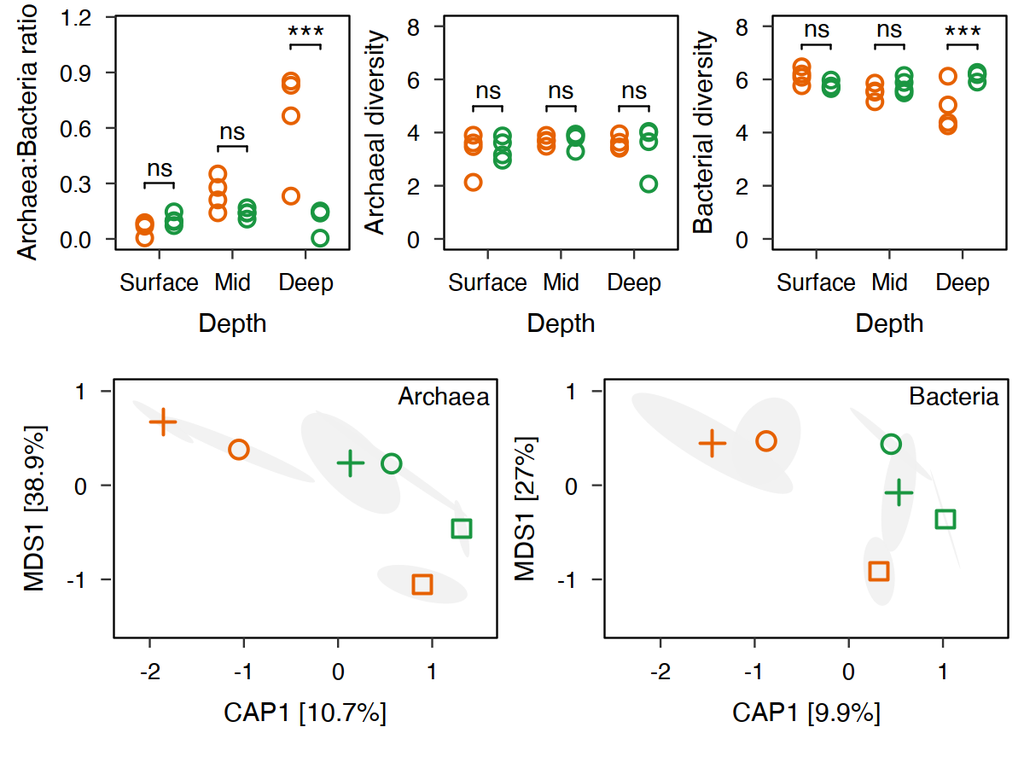

```r
## compose plot
options(repr.plot.width = 10, repr.plot.height = 7.5)
(archaea_to_bacteria_ratio_figure + shannon_diversity_archaea_figure + shannon_diversity_bacteria_figure) /
(archaea_cap_figure + bacteria_cap_figure) + plot_layout(heights = c(3, 4))
```

```r
## export plot
pdf(file.path(figures, "1_main", "1a_diversity.pdf"), width = 10, height = 7.5)
(archaea_to_bacteria_ratio_figure + shannon_diversity_archaea_figure + shannon_diversity_bacteria_figure) /
(archaea_cap_figure + bacteria_cap_figure) + plot_layout(heights = c(3, 4))
dev.off()
```